# Retail project

Leslie

04/06/2020

```r
library(fpp3)
library(readabs)
```

```r
library(ggthemes)
library(ggplot2)
```

Preparation works

```r
# read data from database
set.seed(29172977)
myseries <- aus_retail %>%
  filter(
    `Series ID` == sample(aus_retail$`Series ID`,1),
    Month < yearmonth("2018 Jan")
  )
```

### Report—————————————————————————————————————-

# 1.A discussion of the statistical features of the original data.

```r
head(myseries,n = 36)
```

```
## # A tsibble: 36 x 5 [1M]
## # Key:       State, Industry [1]
##    State         Industry                          `Series ID`    Month Turnover
##    <chr>         <chr>                             <chr>          <mth>    <dbl>
##  1 South Austra~ Electrical and electronic goods ~ A3349361W   1982 Apr     16
##  2 South Austra~ Electrical and electronic goods ~ A3349361W   1982 May     19
##  3 South Austra~ Electrical and electronic goods ~ A3349361W   1982 Jun     18.1
##  4 South Austra~ Electrical and electronic goods ~ A3349361W   1982 Jul     20.3
##  5 South Austra~ Electrical and electronic goods ~ A3349361W   1982 Aug     19.6
##  6 South Austra~ Electrical and electronic goods ~ A3349361W   1982 Sep     19.9
##  7 South Austra~ Electrical and electronic goods ~ A3349361W   1982 Oct     19.7
##  8 South Austra~ Electrical and electronic goods ~ A3349361W   1982 Nov     22.7
##  9 South Austra~ Electrical and electronic goods ~ A3349361W   1982 Dec     30.3
## 10 South Austra~ Electrical and electronic goods ~ A3349361W   1983 Jan     18.8
## # ... with 26 more rows
```

```r
summary(myseries)
```

```
##     State             Industry          Series ID             Month
##  Length:429         Length:429         Length:429         Min.   :1982 Apr
##  Class :character   Class :character   Class :character   1st Qu.:1991 Mar
##  Mode  :character   Mode  :character   Mode  :character   Median :2000 Feb
##                                                           Mean   :2000 Jan
##                                                           3rd Qu.:2009 Jan
##                                                           Max.   :2017 Dec
##     Turnover
##  Min.   : 16.00
##  1st Qu.: 39.10
##  Median : 62.00
##  Mean   : 67.97
##  3rd Qu.: 95.00
##  Max.   :182.30
```

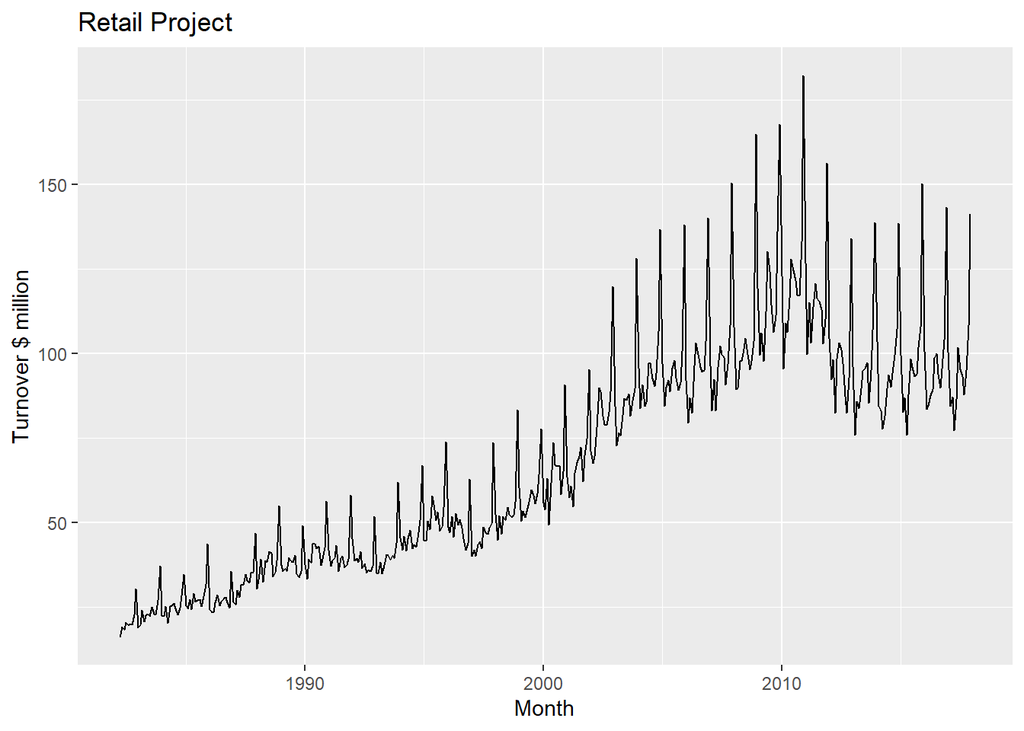

```r
myseries %>%
  autoplot(Turnover) +
  xlab('Month') + ylab('Turnover $ million') +
  ggtitle('Retail Project')
```

```r
min(myseries$Turnover) # 16
```

```
## [1] 16
```

```r
max(myseries$Turnover) # 182.3
```

```
## [1] 182.3
```

This graph is just simply plotted value of Turnover against the time, from April 1982 to Decemeber 2017, using the monthly data. It is easily to see that both trend and seasonal components are included in this series. For the trend component, it can be easily seen that there is an upward trend until year 2010 followed by a wave-pattern from 2010 onward to 2017. It still shows an upward trend if we overlook the wave though, Turnover value arise from 16 million AUD to 182.3 millon AUD.

To investigate whether the sesaonal components exist or not, we could applied the seasonal plot to see if the interval between peak and trough is always of a fixed and known period.

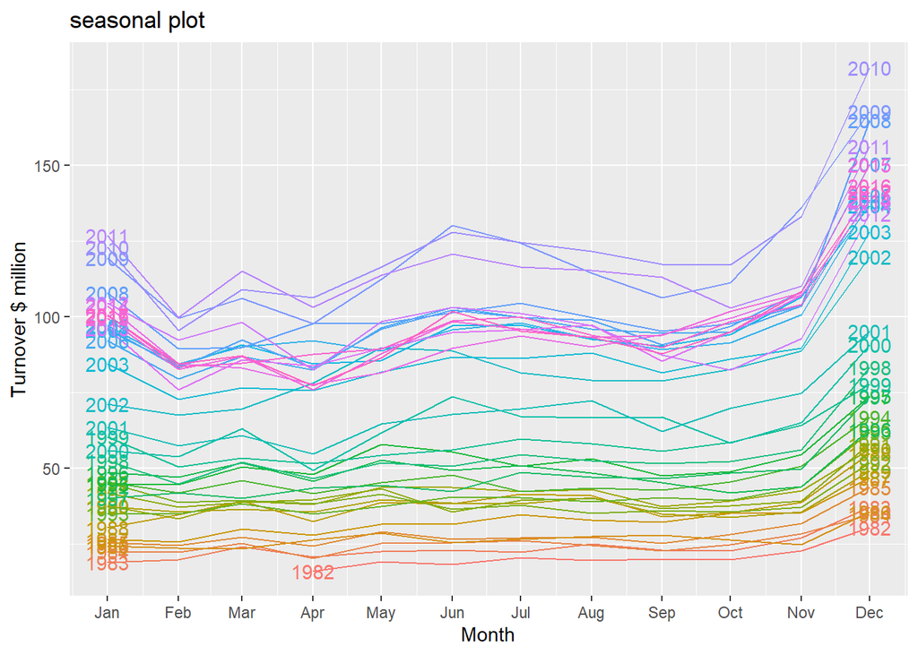

```r
myseries %>%
  gg_season(Turnover,label = "both") +
  ylab('Turnover $ million') +
  ggtitle('seasonal plot')
```

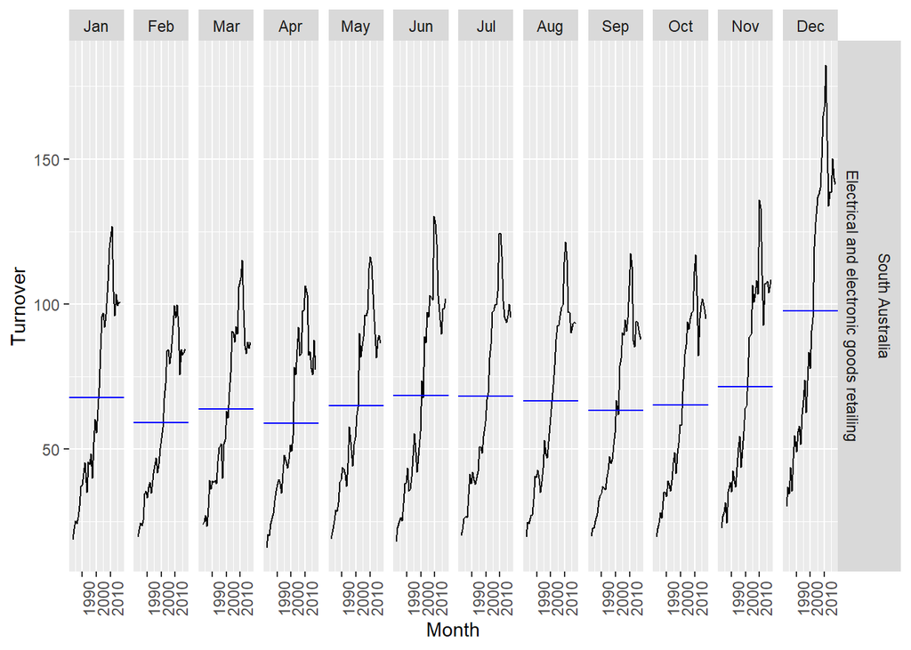

```r
myseries %>%
  gg_subseries(Turnover)
```

# 2.Explanation of transformations and differencing used. You should use a unit-root test as part of the discussion.

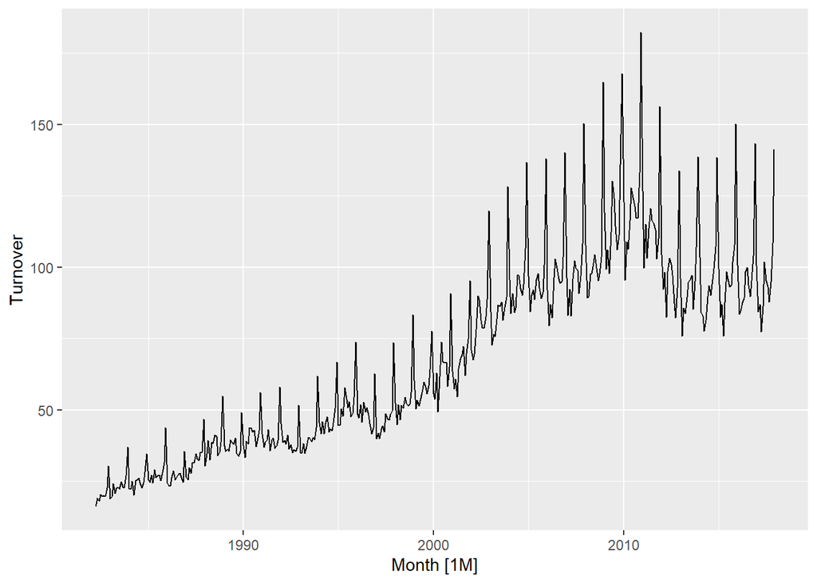

```r
# Plotting the orginal model
myseries %>% autoplot(Turnover)
```

We could conclude that the size of the seasonal variation are not the same across the whole series which suggest that the transformation is necessary, then applying the ‘guerror’ method.

```r
lambda <- myseries %>%
  features(Turnover,features = guerrero) %>%
  pull(lambda_guerrero)

lambda # -0.03996428
```

```
## [1] -0.03996428
```

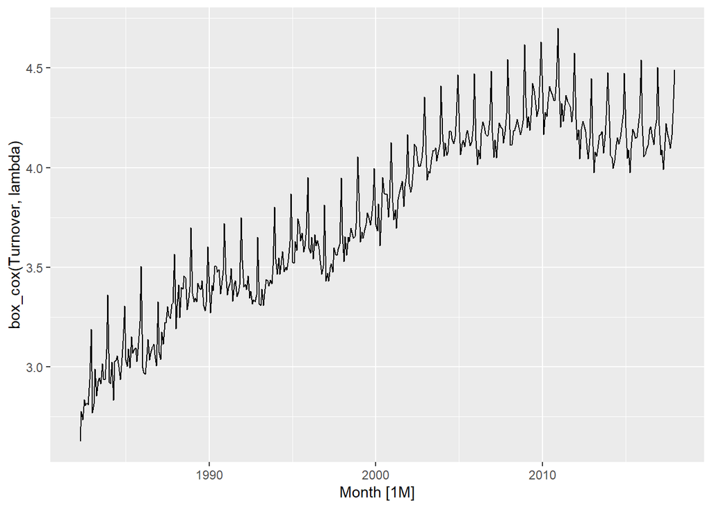

```r
myseries %>%
  autoplot(box_cox(Turnover,lambda))
```

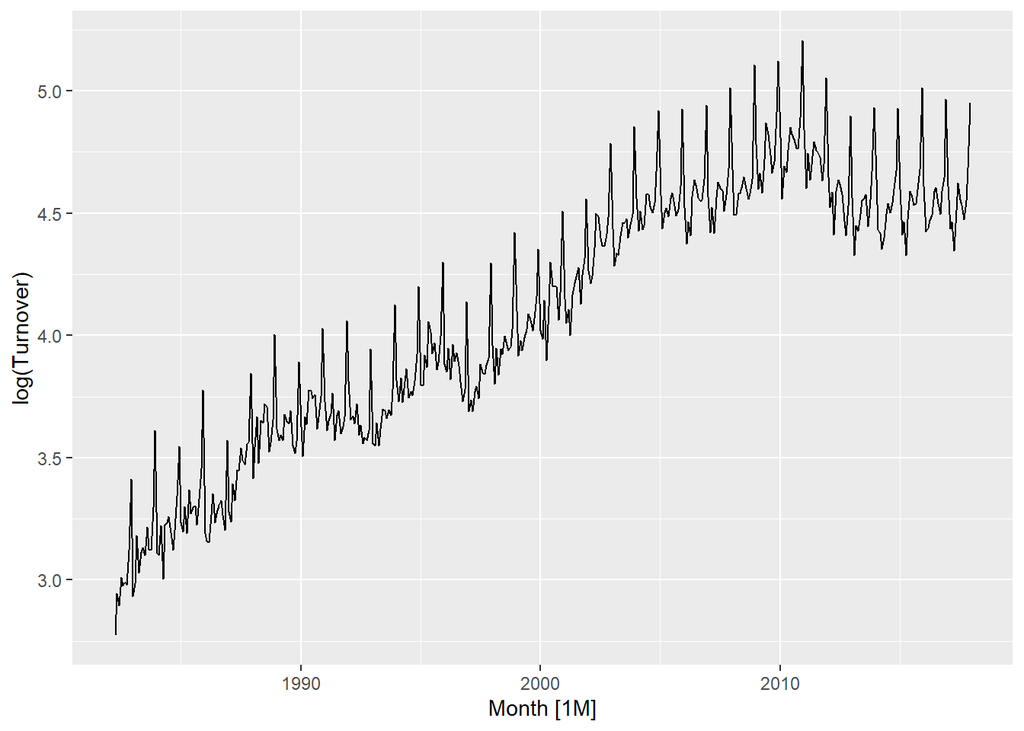

```r
# We could try the log transformation as we are more familiar with the statitical property of logarithmic function.

myseries %>%
  autoplot(log(Turnover))
```

After applying the log transformation, we could see that the variance of data has become realtively stable among time.Since the log transformation still do a reasonable job for us,we would select method of log transformation.

```r
# myseries has 429 rows, so we select the last 24 observations as our testing set and the rest is assumed as the training set

myseries_tr <- myseries %>%
   slice(1:405)
myseries_tr
```

```
## # A tsibble: 405 x 5 [1M]
## # Key:       State, Industry [1]
##    State         Industry                          `Series ID`    Month Turnover
##    <chr>         <chr>                             <chr>          <mth>    <dbl>
##  1 South Austra~ Electrical and electronic goods ~ A3349361W   1982 Apr     16
##  2 South Austra~ Electrical and electronic goods ~ A3349361W   1982 May     19
##  3 South Austra~ Electrical and electronic goods ~ A3349361W   1982 Jun     18.1
##  4 South Austra~ Electrical and electronic goods ~ A3349361W   1982 Jul     20.3
##  5 South Austra~ Electrical and electronic goods ~ A3349361W   1982 Aug     19.6
##  6 South Austra~ Electrical and electronic goods ~ A3349361W   1982 Sep     19.9
##  7 South Austra~ Electrical and electronic goods ~ A3349361W   1982 Oct     19.7
##  8 South Austra~ Electrical and electronic goods ~ A3349361W   1982 Nov     22.7
##  9 South Austra~ Electrical and electronic goods ~ A3349361W   1982 Dec     30.3
## 10 South Austra~ Electrical and electronic goods ~ A3349361W   1983 Jan     18.8
## # ... with 395 more rows
```

```r
myseries_ts <- myseries %>%
  slice(406:429)
myseries_ts
```

```
## # A tsibble: 24 x 5 [1M]
## # Key:       State, Industry [1]
##    State         Industry                          `Series ID`    Month Turnover
##    <chr>         <chr>                             <chr>          <mth>    <dbl>
##  1 South Austra~ Electrical and electronic goods ~ A3349361W   2016 Jan    101.
##  2 South Austra~ Electrical and electronic goods ~ A3349361W   2016 Feb     83.5
##  3 South Austra~ Electrical and electronic goods ~ A3349361W   2016 Mar     84.7
##  4 South Austra~ Electrical and electronic goods ~ A3349361W   2016 Apr     87.5
##  5 South Austra~ Electrical and electronic goods ~ A3349361W   2016 May     89.3
##  6 South Austra~ Electrical and electronic goods ~ A3349361W   2016 Jun     98.5
##  7 South Austra~ Electrical and electronic goods ~ A3349361W   2016 Jul    100
##  8 South Austra~ Electrical and electronic goods ~ A3349361W   2016 Aug     93.8
##  9 South Austra~ Electrical and electronic goods ~ A3349361W   2016 Sep     89.8
## 10 South Austra~ Electrical and electronic goods ~ A3349361W   2016 Oct     98.3
## # ... with 14 more rows
```

It is necessary to difference the dataset ?

```r
# Using the unit-root test
mm <-myseries %>%
  mutate(Turnover = log(Turnover)) %>%
  features(Turnover,unitroot_kpss)

myseries %>%
  features(Turnover,unitroot_ndiffs)
```

```
## # A tibble: 1 x 3
##   State           Industry                                  ndiffs
##   <chr>           <chr>                                      <int>
## 1 South Australia Electrical and electronic goods retailing      1
```

We could also apply seasonal strength and unitroot_nsdiffs to see whether we need to do the seasonal difference

```r
# Method 1 :
myseries %>%
  features(Turnover,unitroot_nsdiffs) # suggest that we need to do seasonal difference once
```

```
## # A tibble: 1 x 3
##   State           Industry                                  nsdiffs
##   <chr>           <chr>                                       <int>
## 1 South Australia Electrical and electronic goods retailing       1
```

```r
# Method 2 :
myseries %>%
  mutate(Turnover = log(Turnover)) %>%
  features(Turnover,list(unitroot_ndiffs,feat_stl)) # since the seasonal_strength is 0.883905 > 0.64, so we need to do one seasonal difference
```

```
## # A tibble: 1 x 12
##   State Industry ndiffs trend_strength seasonal_streng~ seasonal_peak_y~
##   <chr> <chr>     <int>          <dbl>            <dbl>            <dbl>
## 1 Sout~ Electri~      1          0.993            0.884                9
## # ... with 6 more variables: seasonal_trough_year <dbl>, spikiness <dbl>,
## #   linearity <dbl>, curvature <dbl>, stl_e_acf1 <dbl>, stl_e_acf10 <dbl>
```

Check the model after non-seasonal difference once followed by seasonal difference once

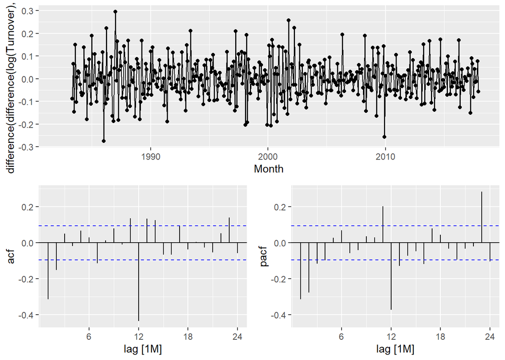

```r
myseries %>% gg_tsdisplay(difference(difference(log(Turnover),12)),lag_max = 24,plot_type = 'partial')
```

```r
myseries %>%
  mutate(Turnover = difference(difference(log(Turnover),12))) %>%
  features(Turnover,unitroot_kpss)
```

```
## # A tibble: 1 x 4
##   State           Industry                                 kpss_stat kpss_pvalue
##   <chr>           <chr>                                        <dbl>       <dbl>
## 1 South Australia Electrical and electronic goods retaili~    0.0194         0.1
```

When doing the kpss test for the 2nd order differencing data, since the p-value now is 0.1 which is bigger than 0.05, so we cannot reject the null hypothesis, then conclude that the 2nd order differencing data is stationary now.

We also used gg_tsdisplay function to see the performance of our 2nd order differencing data, even if the ACF did not declay quickly, but we could see that the time plot seems like a stationary process beacuse it’s mean reverting behaviour.